# MLR

Richard Gan

2023-04-03

Source: Abalone Data Set Data comes from an original (non-machine-learning) study: Warwick J Nash, Tracy L Sellers, Simon R Talbot, Andrew J Cawthorn and Wes B Ford (1994) “The Population Biology of Abalone (*Haliotis* species) in Tasmania. I. Blacklip Abalone (*H. rubra*) from the North Coast and Islands of Bass Strait”, Sea Fisheries Division, Technical Report No. 48 (ISSN 1034-3288)

Original Owners of Database:

Marine Resources Division Marine Research Laboratories - Taroona

Link: http://archive.ics.uci.edu/ml/datasets/Abalone

==================================================================

I. Defining and examining data

```r
library(pacman)

pacman::p_load(tidyverse, psych, pastecs, olsrr, stargazer, ggfortify, caTools, car, quantmod, MASS, corrplot, performance)
```

```r
df = read_csv("Abalone.csv", col_names = T)
view(df)
str(df)
```

```
## spc_tbl_ [4,173 × 9] (S3: spec_tbl_df/tbl_df/tbl/data.frame)
##  $ sex           : chr [1:4173] "M" "M" "F" "M" ...
##  $ length        : num [1:4173] 0.455 0.35 0.53 0.44 0.33 0.425 0.53 0.545 0.475 0.55 ...
##  $ diameter      : num [1:4173] 0.365 0.265 0.42 0.365 0.255 0.3 0.415 0.425 0.37 0.44 ...
##  $ height        : num [1:4173] 0.095 0.09 0.135 0.125 0.08 0.095 0.15 0.125 0.125 0.15 ...
##  $ whole_weight  : num [1:4173] 0.514 0.226 0.677 0.516 0.205 ...
##  $ shucked_weight: num [1:4173] 0.2245 0.0995 0.2565 0.2155 0.0895 ...
##  $ viscera_weight: num [1:4173] 0.101 0.0485 0.1415 0.114 0.0395 ...
##  $ shell_weight  : num [1:4173] 0.15 0.07 0.21 0.155 0.055 0.12 0.33 0.26 0.165 0.32 ...
##  $ rings         : num [1:4173] 15 7 9 10 7 8 20 16 9 19 ...
##  - attr(*, "spec")=
##   .. cols(
##   ..   sex = col_character(),
##   ..   length = col_double(),
##   ..   diameter = col_double(),
##   ..   height = col_double(),
##   ..   whole_weight = col_double(),
##   ..   shucked_weight = col_double(),
##   ..   viscera_weight = col_double(),
##   ..   shell_weight = col_double(),
##   ..   rings = col_double()
##   .. )
##  - attr(*, "problems")=<externalptr>
```

```r
summary(df)
```

```
##      sex                length          diameter          height
##  Length:4173        Min.   :0.0750   Min.   :0.0550   Min.   :0.0000
##  Class :character   1st Qu.:0.4500   1st Qu.:0.3500   1st Qu.:0.1150
##  Mode  :character   Median :0.5450   Median :0.4250   Median :0.1400
##                     Mean   :0.5239   Mean   :0.4078   Mean   :0.1392
##                     3rd Qu.:0.6150   3rd Qu.:0.4800   3rd Qu.:0.1650
##                     Max.   :0.8150   Max.   :0.6500   Max.   :0.2500
##   whole_weight    shucked_weight   viscera_weight    shell_weight
##  Min.   :0.0020   Min.   :0.0010   Min.   :0.0005   Min.   :0.0015
##  1st Qu.:0.4415   1st Qu.:0.1860   1st Qu.:0.0935   1st Qu.:0.1300
##  Median :0.7995   Median :0.3360   Median :0.1710   Median :0.2340
##  Mean   :0.8284   Mean   :0.3592   Mean   :0.1805   Mean   :0.2388
##  3rd Qu.:1.1530   3rd Qu.:0.5015   3rd Qu.:0.2525   3rd Qu.:0.3290
##  Max.   :2.8255   Max.   :1.4880   Max.   :0.7600   Max.   :1.0050
##      rings
##  Min.   : 1.000
##  1st Qu.: 8.000
##  Median : 9.000
##  Mean   : 9.934
##  3rd Qu.:11.000
##  Max.   :29.000
```

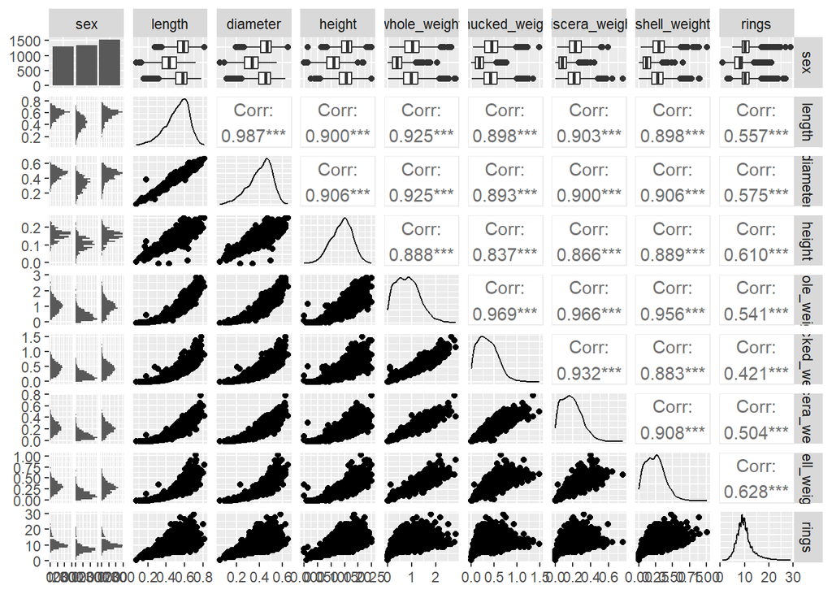

```r
GGally::ggpairs(df)
```

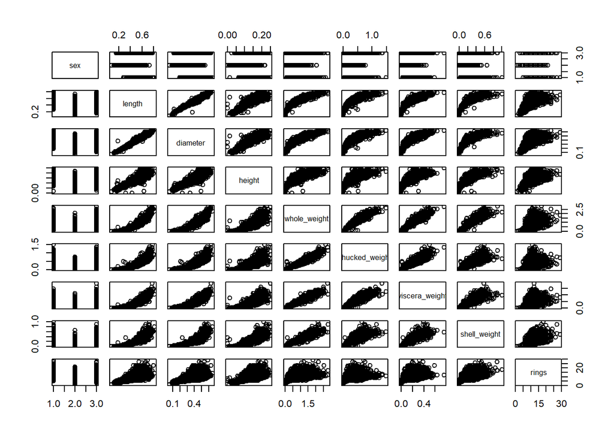

```r
#convert sex column from char to factor (3 levels or 2 dummy var)
#needed to run pairs function
df$sex = as.factor(df$sex)
pairs(df)
```

2. Linear Model

```r
model <- lm(rings ~ sex + length + diameter + height + whole_weight + shucked_weight + viscera_weight + shell_weight, data = df)
summary(model) #We can see on the summary that Length is not significant
```

```
##
## Call:
## lm(formula = rings ~ sex + length + diameter + height + whole_weight +
##     shucked_weight + viscera_weight + shell_weight, data = df)
##
## Residuals:
##     Min      1Q  Median      3Q     Max
## -8.3827 -1.3142 -0.3356  0.8759 14.1525
##
## Coefficients:
##                 Estimate Std. Error t value Pr(>|t|)
## (Intercept)      3.56908    0.29315  12.175  < 2e-16 ***
## sexI            -0.78744    0.10191  -7.727 1.38e-14 ***
## sexM             0.05818    0.08286   0.702    0.483
## length          -1.16691    1.80110  -0.648    0.517
## diameter         9.19179    2.22772   4.126 3.76e-05 ***
## height          23.40453    2.27874  10.271  < 2e-16 ***
## whole_weight     8.75920    0.72404  12.098  < 2e-16 ***
## shucked_weight -19.29914    0.81663 -23.633  < 2e-16 ***
## viscera_weight -11.08849    1.28795  -8.609  < 2e-16 ***
## shell_weight     7.86620    1.13343   6.940 4.52e-12 ***
## ---
## Signif. codes:  0 '***' 0.001 '**' 0.01 '*' 0.05 '.' 0.1 ' ' 1
##
## Residual standard error: 2.18 on 4163 degrees of freedom
## Multiple R-squared:  0.544,  Adjusted R-squared:  0.543
## F-statistic: 551.8 on 9 and 4163 DF,  p-value: < 2.2e-16
```

```r
model1 <- ols_step_backward_aic(model, details=TRUE)
```

```
## Backward Elimination Method
## ---------------------------
##
## Candidate Terms:
##
## 1 . sex
## 2 . length
## 3 . diameter
## 4 . height
## 5 . whole_weight
## 6 . shucked_weight
## 7 . viscera_weight
## 8 . shell_weight
##
##  Step 0: AIC = 18359.98
##  rings ~ sex + length + diameter + height + whole_weight + shucked_weight + viscera_weight + shell_weight
##
## --------------------------------------------------------------------------------
## Variable          DF       AIC        Sum Sq        RSS       R-Sq     Adj. R-Sq
## --------------------------------------------------------------------------------
## length            1     18358.399       1.995    19792.324    0.544        0.543
## diameter          1     18375.009      80.933    19871.261    0.542        0.541
## shell_weight      1     18405.983     228.975    20019.304    0.539        0.538
## viscera_weight    1     18431.624     352.363    20142.692    0.536        0.535
## sex               1     18440.767     406.222    20196.550    0.535        0.534
## height            1     18462.403     501.482    20291.811    0.532        0.532
## whole_weight      1     18502.164     695.745    20486.074    0.528        0.527
## shucked_weight    1     18883.323    2655.051    22445.379    0.483        0.482
## --------------------------------------------------------------------------------
##
##
## Variables Removed:
##
## - length
##
##
##   Step 1 : AIC = 18358.4
##  rings ~ sex + diameter + height + whole_weight + shucked_weight + viscera_weight + shell_weight
##
## --------------------------------------------------------------------------------
```

[output cut: 42 more lines]

```
##
##                                       Parameter Estimates
## -----------------------------------------------------------------------------------------------
##          model       Beta    Std. Error    Std. Beta       t        Sig       lower      upper
## -----------------------------------------------------------------------------------------------
##    (Intercept)      3.509         0.278                  12.620    0.000      2.964      4.054
##           sexI     -0.792         0.102       -0.115     -7.783    0.000     -0.991     -0.592
##           sexM      0.058         0.083        0.009      0.697    0.486     -0.105      0.220
##       diameter      7.917         1.045        0.244      7.575    0.000      5.868      9.966
##         height     23.315         2.274        0.278     10.251    0.000     18.856     27.774
##   whole_weight      8.765         0.724        1.332     12.108    0.000      7.346     10.185
## shucked_weight    -19.341         0.814       -1.329    -23.762    0.000    -20.937    -17.746
## viscera_weight    -11.165         1.282       -0.379     -8.706    0.000    -13.679     -8.651
##   shell_weight      7.893         1.133        0.341      6.970    0.000      5.673     10.114
## -----------------------------------------------------------------------------------------------
```